# Better figures with ggplot2

PCB 6455 / BSC 4933: Biometry | Lecture 8

Dr. Brian Maitner

## Today’s agenda

1. One variable: distributions
2. Two variables: which plot depends on the kind of data
3. More than two variables: color, fill and facets
4. Finishing a figure: labels and saving

## The story so far

**Lectures 5 and 6:** base R plots: `hist()`, `plot()`, `boxplot()`.

**Lecture 7:** dplyr, and the pipe.

**Today:** the tidyverse’s plotting package, which takes the pipe’s output directly.

# Getting started

## ggplot2

**A package in the tidyverse.**

**“gg” refers to “grammar of graphics”**, a consistent format for plotting.

**Offers a lot of options** for publication-quality figures.

**Additional packages** (usually starting with “gg”) add more features.

**Syntax can be tricky at first.**

## Getting set up

`ggridges` is new. Install it first if you need to:

```r
install.packages("ggridges")
```

```r
library(tidyverse)
library(ggridges)
avo <- read_rds("https://tinyurl.com/avonetbirddata")
```

**Go ahead and run this.**

## Understanding ggplot

Today, we’re going to work through some examples.

We’ll start with single variables, then work up to more complicated figures.

# One variable

## Distributions

Let’s start with the single variable case and look at distributions.

**Base R:**

```r
hist(avo$Hand.Wing.Index)
```

**ggplot:**

```r
avo |>
  ggplot(mapping = aes(x = Hand.Wing.Index)) +
  geom_histogram()
```

**Try this out now and examine the output.**

## Distributions

You could also use a density plot:

```r
avo |>
  ggplot(mapping = aes(x = Hand.Wing.Index)) +
  geom_density()
```

**Try this out now and examine the output.**

## ggplot syntax

```r
avo |>
  ggplot(mapping = aes(x = Hand.Wing.Index)) +
  geom_histogram()
```

**`aes()`** maps data to plot elements.

**`geom_histogram()`** tells ggplot what type of plot to make.

**What happens if we omit the “geom_histogram” bit?**

**Check:** an empty plot: the axis is set up from the mapping, but nothing is drawn on it.

## ggplot syntax

```r
avo |>
  ggplot(mapping = aes(x = Hand.Wing.Index)) +
  geom_histogram()
```

**Plot functions begin with “geom_”.**

**What are some of the other “geom_” options?** (hint: use tab completion)

**Do they result in a figure if we call them instead of geom_histogram?**

**Check:** some do (`geom_density()`, `geom_freqpoly()`, `geom_dotplot()`); others stop with an error such as “`geom_point()` requires the following missing aesthetics: y”.

# Two variables

## Two variables

Options depend on type of data:

|  | **y continuous** | **y categorical** |
| --- | --- | --- |
| **x continuous** | `geom_point`, `geom_line` | `geom_density_ridges`, `coord_flip()`-ed versions |
| **x categorical** | `geom_bar`, `geom_boxplot`, `geom_violin` | `geom_tile`, `geom_raster` |

# Continuous x, continuous y

## geom_point

```r
avo |>
  ggplot(mapping = aes(x = Hand.Wing.Index,
                       y = Kipps.Distance)) +
  geom_point()
```

**Try this out. Then, plot two other continuous variables.**

## geom_point

```r
avo |>
  ggplot(mapping = aes(x = Hand.Wing.Index,
                       y = Kipps.Distance)) +
  geom_point()
```

**How would we plot a line showing the relationship between the two?**

## Lines

Three main approaches:

| Function | What it does | Here? |
| --- | --- | --- |
| `geom_line()` | adds a line connecting adjacent points | doesn’t work in this case |
| `geom_abline()` | allows you to add a line you specify | good option here if we fit a line first |
| `geom_smooth()` | fits a line for you and adds it | good option here |

## geom_line()

```r
avo |>
  ggplot(mapping = aes(x = Hand.Wing.Index,
                       y = Kipps.Distance)) +
  geom_line()
```

**Try this out. Is it useful?**

**Check:** no. It joins all 11,009 points in order of x, so it zigzags up and down between birds with similar wings.

## geom_line()

```r
avo |>
  mutate(rounded_hwi = round(Hand.Wing.Index)) |>
  group_by(rounded_hwi) |>
  summarise(mean_kipps = mean(Kipps.Distance)) |>
  ggplot(mapping = aes(x = rounded_hwi,
                       y = mean_kipps)) +
  geom_line()
```

**Try this one. Is this useful?**

## geom_abline()

With this, we can add a fitted line to a plot.

First, we need to decide on a line, or model one:

```r
kipps_v_hwi_model <- avo |>
  lm(formula = Kipps.Distance ~ Hand.Wing.Index)
```

**What data do we need from the model to plot the fitted line?**

**Check:** the intercept and the slope, -15.08 and 2.04.

## geom_abline()

```r
ggplot(data = avo,
       mapping = aes(x = Hand.Wing.Index,
                     y = Kipps.Distance)) +
  geom_point() +
  geom_abline(slope = kipps_v_hwi_model$coefficients[2],
              intercept = kipps_v_hwi_model$coefficients[1],
              color = "blue")
```

**Run this. How does it look? Any changes you’d want to make?**

## geom_smooth()

Fits a line for you. By default it fits a flexible curve: **loess** (a local smoother) for fewer than 1,000 points, or a **GAM** (generalized additive model) for more. In many cases, we want an lm instead.

```r
ggplot(data = avo,
       mapping = aes(x = Hand.Wing.Index,
                     y = Kipps.Distance)) +
  geom_point() +
  geom_smooth()
```

**Run this now. How does the fitted line look?**

## geom_smooth()

```r
ggplot(data = avo,
       mapping = aes(x = Hand.Wing.Index,
                     y = Kipps.Distance)) +
  geom_point() +
  geom_smooth(method = "lm")
```

**Run this. How does it compare with the plot you made using `geom_abline`?**

**Check:** the same line, plus a grey band around it.

# Categorical x, continuous y

## geom_bar

```r
avo |>
  group_by(Order1) |>
  summarise(mean_mass = mean(Mass)) |>
  slice_max(n = 5, order_by = mean_mass) |>
  ggplot(mapping = aes(y = mean_mass, x = Order1)) +
  geom_bar(stat = "identity")
```

**Try this out. Then, try it for different variable(s).**

## geom_bar

By default, `geom_bar` uses count data.

We forced it to use the raw data we gave it (`mean_mass`).

Let’s try the default setting.

## geom_bar

```r
avo |>
  filter(Order1 %in% c("Struthioniformes",
                       "Cathartiformes",
                       "Gaviiformes",
                       "Sphenisciformes",
                       "Ciconiiformes")) |>
  ggplot(mapping = aes(x = Order1)) +
  geom_bar()
```

**Try this one. Why don’t we have to specify y in the aesthetics?**

**Check:** `geom_bar()` counts the rows for each order, and that count is the y.

## geom_boxplot

```r
avo |>
  filter(Order1 %in% c("Struthioniformes",
                       "Cathartiformes",
                       "Gaviiformes",
                       "Sphenisciformes",
                       "Ciconiiformes")) |>
  ggplot(mapping = aes(x = Order1,
                       y = Wing.Length)) +
  geom_boxplot()
```

**Run this now. Who remembers what the different features denote?**

## geom_boxplot

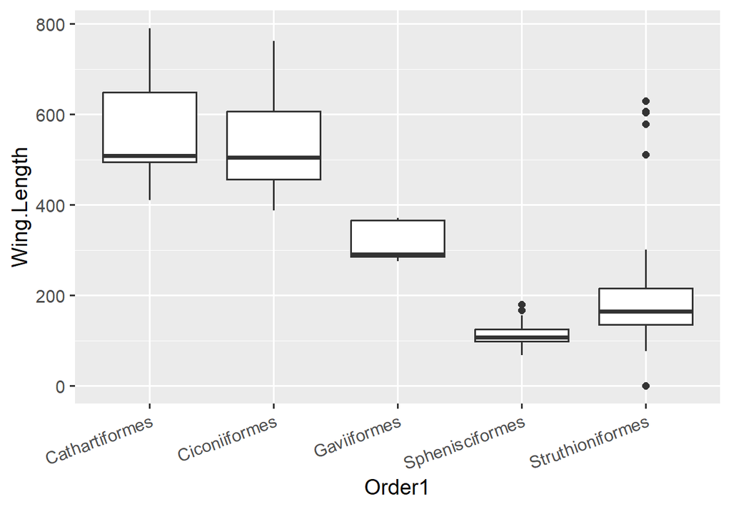

**Horizontal line:** median

**Hinges:** Q1 and Q3

**Whiskers:** furthest data within 1.5 × IQR from Q1/Q3

**IQR:** Q3 − Q1

**Dots:** outliers (points outside the whiskers)

## geom_violin

A sort of combination of a density plot and a boxplot.

It contains more information than a boxplot.

**Revise the code we used for our boxplot to make a violin plot instead.**

## Box vs violin

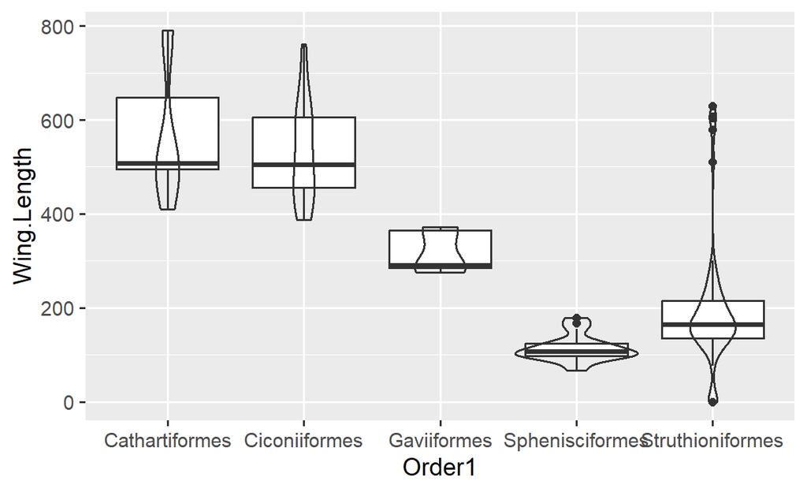

# Continuous x, categorical y

## Flip the axes

Same functions as for categorical x and continuous y: just flip the x and y variables. You can also use `coord_flip()`:

```r
avo |>
  group_by(Order1) |>
  summarise(mean_mass = mean(Mass)) |>
  slice_max(n = 5, order_by = mean_mass) |>
  ggplot(mapping = aes(y = mean_mass, x = Order1)) +
  geom_bar(stat = "identity") +
  coord_flip()
```

**Try this one out.**

## Joy plots (aka ridgeline plots)

**Inspired by Joy Division’s album**, *Unknown Pleasures* (1979).

**Essentially a stacked set of distributions.**

**Implemented in R using** `geom_density_ridges()`.

The cover is itself a plot: radio pulses from pulsar CP 1919, stacked.

[figure not shown]

Album cover: Joy Division, *Unknown Pleasures* (Factory Records, 1979), design by Peter Saville.

## geom_density_ridges

```r
avo |>
  group_by(Order1) |>
  mutate(mean_mass = mean(Mass)) |>
  filter(Order1 %in% c("Struthioniformes",
                       "Cathartiformes",
                       "Gaviiformes",
                       "Sphenisciformes",
                       "Ciconiiformes")) |>
  ggplot(mapping = aes(x = Wing.Length,
                       y = Order1,
                       group = Order1)) +
  geom_density_ridges()
```

**Try this out!**

# Categorical x, categorical y

## Not a common thing

Categorical by categorical plots are not a common thing.

Sometimes done to show the counts in the different categories.

## geom_count

```r
avo |>
  filter(Family1 %in% c("Psittacidae", "Cacatuidae")) |>
  ggplot(mapping = aes(x = Family1, y = Habitat)) +
  geom_count()
```

**Try this out. Are there situations where it might be useful?**

## geom_tile

```r
avo |>
  group_by(Family1, Trophic.Level) |>
  mutate(n_species = n(),
         log10_species = n() |> log10()) |>
  filter(Family1 %in% c("Psittacidae", "Cacatuidae")) |>
  ggplot(mapping = aes(x = Family1,
                       y = Trophic.Level,
                       fill = log10_species)) +
  geom_tile()
```

**Try this one out as well.**

# More than two variables

## More than 2 variables?

When you have more than two variables, options include:

| Option | Example |
| --- | --- |
| color / fill | `aes(color = Habitat)` |
| shape / line type | `aes(shape = Trophic.Level)` |
| size | `aes(size = Mass)` |
| faceting | `facet_wrap(~ Family1)` |

## Color and fill

Color is used for lines and points, fill for polygons. Example of using color to show three variables:

```r
avo |>
  filter(Family1 %in% c("Psittacidae", "Cacatuidae")) |>
  group_by(Family1, Habitat) |>
  summarise(mean_mass = mean(Mass)) |>
  slice_max(n = 5, order_by = mean_mass) |>
  ggplot(mapping = aes(y = mean_mass,
                       x = Family1, fill = Habitat)) +
  geom_bar(stat = "identity", position = "dodge")
```

**Try this one out.**

## Faceting

`facet_wrap` and `facet_grid` split up plots into different facets.

**Try out this example:**

```r
avo |>
  filter(Family1 %in% c("Psittacidae", "Cacatuidae")) |>
  ggplot(mapping = aes(x = Mass,
                       y = Wing.Length)) +
  geom_point() +
  facet_wrap(~Family1)
```

## Faceting

Facet grid allows you to have plots divided into rows and columns.

```r
avo |>
  filter(Family1 %in% c("Psittacidae", "Cacatuidae")) |>
  ggplot(mapping = aes(x = Mass,
                       y = Wing.Length)) +
  geom_point() +
  facet_grid(Family1 ~ Trophic.Niche)
```

**Try this one out as well. Note the structure of the facet_grid arguments (y ~ x).**

# Finishing a figure

## Labeling your figure

```r
avo |>
  ggplot(mapping = aes(x = Hand.Wing.Index,
                       y = Kipps.Distance)) +
  geom_point(alpha = 0.1) +
  geom_smooth(method = "lm") +
  labs(title = "Kipp's distance rises with hand-wing index",
       x = "Hand-wing index",
       y = "Kipp's distance (mm)",
       caption = "Data: AVONET") +
  theme_bw()
```

One function, multiple labels.

## Saving your figure

```r
my_plot <- avo |>
  ggplot(mapping = aes(x = Mass, y = Wing.Length)) +
  geom_point()

ggsave(filename = "my_figure.png",
       plot     = my_plot,
       width    = 8,
       height   = 5,
       dpi      = 300)
```

**No `dev.off()`. No blank Plots pane.**

**Leave out `plot =` and it saves the last one you made.**

## Soooo many more options

What we’ve done today only scratches the surface.

There are many ways of combining plots, customizing, etc.

There are lots of blogs and tutorials to look at once you have the basics down.

Check out the cheat sheet: rstudio.github.io/cheatsheets/html/data-visualization.html

# Wrapping up

## Which tool, when

| You want to see | Use |
| --- | --- |
| one continuous variable | `geom_histogram()`, `geom_density()` |
| two continuous variables | `geom_point()`, plus `geom_smooth(method = "lm")` for a line |
| a number across groups | `geom_boxplot()`, `geom_violin()`, `geom_density_ridges()` |
| counts per category | `geom_bar()` |
| a value you calculated, per category | `geom_bar(stat = "identity")` |
| a third variable | `color =`, `fill =`, `shape =` or `size =` inside `aes()` |
| one panel per group | `facet_wrap(~ group)`, `facet_grid(rows ~ cols)` |
| a finished figure | `labs()`, `theme_bw()`, `ggsave()` |

## Before next class

Read **Bolker 3.1 to 3.3**

Next time: deterministic functions

**Assignment 1 due tomorrow, Friday, 11:59 pm**